# R Tutorial for Columbia Postgrads

Ben Levine, *@blevined

2017-09-10

# Prologue: What are we doing, anyway?

1. Become familiar with the RStudio environment
2. Objects in R
3. Basic R functions

## RStudio Familiarity

RStudio is a visual environment to run R. Most people find it easier than coding into a standalone text editor and executing commands into the terminal. [Here’s a cheatsheet, which is helpful for keyboard shortcuts](https://www.rstudio.com/wp-content/uploads/2015/01/rstudio-ide-cheatsheet-800x618.png) It has four quadrants.

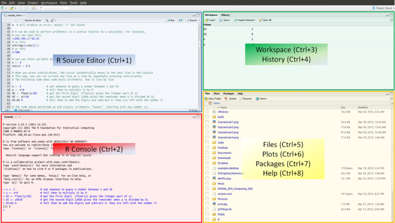

(Ignore the keyboard shortcuts for now, they’re for Windows computers… *yuck!*)

- The *Source Editor* is where you will write your code.
- The *Console* is where you execute it.
- The *Workspace/Environment & History* tab allow you to toggle back and forth between what you currently have loaded (Workspace/Environment), and past commands you have run (History).
- We will use the final quadrant primarily to view our plots and to access the Help pages when we get stuck.  
  **Note:** If you ever want to pull up the documentation for a specific function, you can run `?curiousfunction` in the Console and it will pull up the help page in this final quadrant.

## R as a calculator

We can use R as a basic calculator. Try entering

- `5 + 7`
- `(63/9) + 3*4`
- `sum(1:7)*2`  
  **Note:** the `:` sign effectively means “through.” So, this command reads: “Sum all numbers 1 through 7 (inclusive), then multiply that sum by 2”

You can also assign a value to a variable. For example:

- `x = 7`  
  **Note:** Look in the Environment tab…

You can now use `x` in place of any of the 7’s in the above calculations. Do it! Be carefull though, *R is case sensitive.* You’re doing great!

## Objects in R

There are many different classes of objects in R. The few that we will go to are the most common in our work, but this list is by no means exhaustive.

#### 1. Vectors

Think of a vector as a column. It is an ordered sequence of homogenous data elements, that is, a column of data of the *same basic class*.

> *What are the different data classes?*

Glad you asked!

- **Logical:** binary, either `TRUE` or `FALSE`.
- **Numeric:** this is a number. Also known as a “double” (often shown as `dbl`). There are differences between a “double” and “numeric,” but they are pedantic and unimportant.
- **Integer:** this is a whole number. We won’t use these much.
- **String:** this is one or more character, encapsulated by quotation marks. For example `"Hello world"` is a string. So is `"4"` - but only if you put it in quotes!
- **Factors:** Factors are variables in R which take on a limited number of different values; such variables are often refered to as categorical variables. One of the most important uses of factors is in statistical modeling; since categorical variables enter into statistical models differently than continuous variables, storing data as factors insures that the modeling functions will treat such data correctly. Factors in R are stored as a vector of integer values with a corresponding set of character values to use when the factor is displayed.
- **Dates:** This is a special case. Dates aren’t a “base R” object class, but is a class that can be created with the `lubridate` package. Don’t worry - we’ll get to them later!
- **Special Cases, to Infinity & Beyond:** R cannot hold a value blank, in the same way Excel can. Instead, it stores that “blank” value as `NA` or `NaN`, a null value. This will be helpful in the future. R can handle infinity, whereas Excel cannot. The notation for an infinite value is `Inf`, or `-Inf` if it is negative.

> *But how can I tell what type of data class something is?*

Glad you asked! R has a very useful function called `typeof()`.

> *What’s a function?*

To use the lingo, we call functions and give them arguments. They return an output. For example, `sum(1,2,3,4,5)` is a function that takes numeric **arguments** and whose output **returns** a numeric as well, equal to the sum of all the arguments. Simple, right? More on this later - we can actually define our own functions, but later on. [This](https://nicercode.github.io/guides/functions/) is nice as an intro, if you’re interested. Often, the functions we need to complete a certain task are not new, and other people have written functions to do them. Many folks are nice enough to bundle their written functions into packages that we can download from the internet; we do so by running `install.packages("packagename")`, which stores the package in a refrenceable library. In order to be able to reference the functions contained in the packages, we must load it into our current R session by using `library(packagename)`, and - violà - we can now use their functions. We should have already done this with the “tidyverse” (which is actually a package of packages, but I digress), but if not, do it now.

#### 2. Lists

Lists are great for when you get further into your R journey. Lists are the data structure R uses for complex, hierarchical objects. We can create them by calling the `list()` function. You’re already familiar with vectors, R’s data structure for 1d objects. Lists extend these ideas to model objects that are like trees. You can create a list of data frames, and apply the same function to all of them independently. You can create a hierarchical structure with a list because unlike vectors, a list can contain other lists. For those interested, read more about their power and how to work with them [here](http://r4ds.had.co.nz/lists.html).

#### 3. Data Frames

R’s base data structures can be organised by their dimensionality (1d, 2d, or nd) and whether they’re homogeneous (all contents must be of the same type) or heterogeneous (the contents can be of different types).

Both a matrix and a data frame are 2 dimensional data structure. While a matrix is homogeneous, data frame is not.

##### Aside: Vectors & Matrices

Both matrices and data frames are composed of row and column vectors. We can create vectors by **c**ombining values. We do so as follows:

```r
c(1,10,100)
```

```
[1]   1  10 100
```

```r
j[1,] = j[1,]*3
```

[output not shown]

```r
ifelse(1>20, "ben is smart", "he's really not that smart")

#But what if we wanted to loop through a vector and apply that test to each element?

k

ifelse(k>20,"ben is smart", "he's really not that smart")
```

[output not shown]

We can also ‘nest’ these `ifelse()` statements, so that we can apply multiple tests in the same line!

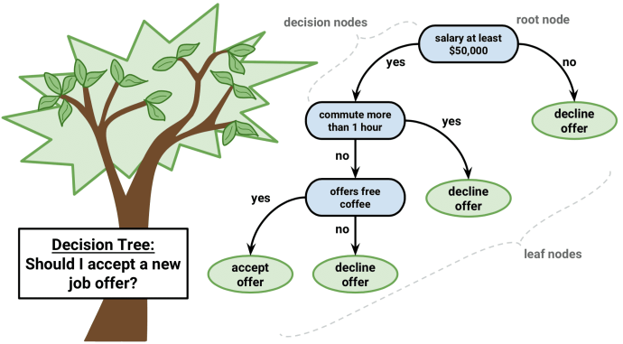

Ok - back to data frames. We can coerce our `j` matrix to a data frame by running `data.frame(j)`; let’s store it as `df`. Let’s create a new column, equal to my friend’s names: “James”, “Sharkey”, “Rebecca.” How would we do that?

```r
df[,4 = "names"] = c("James","Sharkey", "Rebecca")
```

[output not shown]

But that’s syntactically a little complicated, and what if your data was arranged in a different order? We would be assigning the names to data that they don’t correspond to. It’s often helpful to create variables as functions of other variables. So, let’s do this a little more clearly, using the tidyverse.

Let’s work with real data! I emailed you all a dataset of Portugese wines.

### Loading Data into R

Let’s explore the dataset. To view it the way one would in Excel, run: `View(vino)`. Great! But often this is cumbersome and slow, especially as you work with larger and larger datasets. It’s usually faster to call `head()` on the data frame you are working with, as it prints directly to the console so you don’t interrupt your workflow, and only shows you the first six rows of data. But, even this is also missing some information - namely, what kind of entry each is - we call this the **structure** of the dataset. to get the structure of the data frame, run `str()` on ‘vino.’ It looks like we’re going to have to clean up some things - namely, there’s an extra variable called ‘X’ that doesn’t hold any information other than the row numbers, and our coding for red vs. white wine is a Factor variable, and we want to store it as a character, or ‘string’, variable. Time to get wranglin’. [This is helpful as a reference](https://www.rstudio.com/wp-content/uploads/2015/02/data-wrangling-cheatsheet.pdf) (I use it ALL the time). Important functions we’ll be using: * `select()` * `filter()` * `mutate()` * `summarize()`  
And we can chain them togther using this `%>%`, which is called a pipe. The pipe places the output of the preceding action into the first argument of the next function. I like thinking about it/reading it as “then.” In data frames, we can also reference columns by name by using `$`, this takes the form `data_frame_name$column_name`

```r
head(cleaned == cleaned2)
```

[output not shown]

[output not shown]

```r
facts_by_rating = vino %>%  group_by(quality) %>% summarize(abv = mean(alcohol), sulph = mean(sulphates), fruits = mean(citric.acid), sugars = mean(residual.sugar))

#To make it easier to read, I often indent like this:
facts_by_rating = vino %>%  group_by(quality) %>% summarize(abv = mean(alcohol),
                                                            sulph = mean(sulphates),
                                                            fruits = mean(citric.acid),
                                                            sugars = mean(residual.sugar))
```

We can plot this data if we want, too. [Here’s the corresponding cheatsheet](https://www.rstudio.com/wp-content/uploads/2015/03/ggplot2-cheatsheet.pdf)

[figure not shown]

### Writing/Saving Data

The same way we can read data into R, we can write it out into a number of different formats. We’ll just write it out to a csv here:

```r
write.csv(facts_by_rating, "/Users/blevine22/Downloads/myfilename.csv")
```